# Orientation: L1 vs L2

## Data analysis

We have 152 subjects in total and 2432 observations. The subjects are distributed as follows:

```
# A tibble: 9 x 3
# Groups:   LangLev [?]
  LangLev   List `n_distinct(Subject)`
   <fctr> <fctr>                 <int>
1      A2      0                    32
2      A2      1                    25
3      B1      0                    25
4      B1      1                    12
5     B2+      0                    16
6     B2+      1                    11
7      L1      0                    13
8      L1      1                    17
9    <NA>      0                     1
```

After removal of entries with missing data due to “No answers”, we have 151 subjects in total and 1986 observations left. The subjects are distributed as follows:

```
# A tibble: 8 x 3
# Groups:   LangLev [?]
  LangLev   List `n_distinct(Subject)`
   <fctr> <fctr>                 <int>
1      A2      0                    32
2      A2      1                    25
3      B1      0                    25
4      B1      1                    12
5     B2+      0                    16
6     B2+      1                    11
7      L1      0                    13
8      L1      1                    17
```

## Model Building

We set up a categorical variable, `LangLev`, to inform about the speakers L1 and L2 and a another categorical variable, `Type`, to inform about the `Type` of question MATCH and MISMATCH. Further, each different question is identified by the variable `Trial` that we treat also as a categorical variable, since we assume no influence of the order in which the question was posed. We record in the variable `List` the list from which the question is drawn, that is, list A or list B. The response variable is reaction time measured in milliseconds.

We are not intersted in the effect of the specific trials or the specific subjects. However, we are interested in knowing whether these effects are important for the variance of responses. Hence, we specify a mixed effects model with *random effects* associated to the factors `Trial` and `Subject` and *fixed effects* associated with the other factors. Due to the fact that we split trials between two lists and administered the two lists to different subjects the random effects of `Trial` and `Subject` are nested within `List`. Further, for the way we split trials, `Trial` is nested also within `Type`. Within the nesting structure subjects and questions are fully crossed. We fit our model in R using the package `lme4` [Douglas Bates, Martin Maechler, Ben Bolker, Steve Walker (2015). Fitting Linear Mixed-Effects Models Using lme4. Journal of Statistical Software, 67(1), 1-48. doi:10.18637/jss.v067.i01]. As far as the fixed effects are concerned, we are interested in the fixed effects of `LangLev`, `Type` and their interaction. We expect no effect by `List` but we include it in the model to test our expectation.

The distribution of reaction times has longer tail on the right and never reaches zero. Under these conditions, logarithm transformation or generalized linear mixed models with Gamma family and log link function are common approaches to meet the assumptions underlying mixed linear models. In our case, we found that a log-transformed response variable improved considerably the diagnostic plots (conditional and marginal residual qqplots) of the selected models. A Gamma family transformation with log link function yield much worse diagnostic plots.

Hence, considering the design explained above and the goals of this study we analyze the following model is:

```r
lmm<- lmer(log(Time) ~ Type + LangLev + List + Type:LangLev + (1 | List:Subject)+ (1 | List:Type:Trial),
           data = DLM, REML=FALSE)
```

## Likelihood Ratio Tests

The random effects are significant.

```r
lm.0 <- lm(log(Time) ~ 1, data = DLM)
# LeaYrs AECI AMGE
lmm.0 <- lmer(log(Time) ~ (1 | List:Subject)+ (1 | List:Subject:Trial), data = DLM)
AIC(lm.0,lmm.0)
```

```
      df  AIC
lm.0   2 2939
lmm.0  4 2506
```

```r
lmm.4 <- update(lmm,.~.-(1 | List:Subject))
anova(lmm.4,lmm)
```

```
Data: DLM
Models:
lmm.4: log(Time) ~ Type + LangLev + List + (1 | List:Type:Trial) + Type:LangLev
lmm: log(Time) ~ Type + LangLev + List + Type:LangLev + (1 | List:Subject) +
lmm:     (1 | List:Type:Trial)
      Df  AIC  BIC logLik deviance Chisq Chi Df Pr(>Chisq)
lmm.4 11 2672 2734  -1325     2650
lmm   12 2288 2355  -1132     2264   387      1     <2e-16 ***
---
Signif. codes:  0 '***' 0.001 '**' 0.01 '*' 0.05 '.' 0.1 ' ' 1
```

```r
lmm.5 <- update(lmm,.~.-(1 | List:Type:Trial))
anova(lmm.5,lmm)
```

```
Data: DLM
Models:
lmm.5: log(Time) ~ Type + LangLev + List + (1 | List:Subject) + Type:LangLev
lmm: log(Time) ~ Type + LangLev + List + Type:LangLev + (1 | List:Subject) +
lmm:     (1 | List:Type:Trial)
      Df  AIC  BIC logLik deviance Chisq Chi Df Pr(>Chisq)
lmm.5 11 2480 2541  -1229     2458
lmm   12 2288 2355  -1132     2264   194      1     <2e-16 ***
---
Signif. codes:  0 '***' 0.001 '**' 0.01 '*' 0.05 '.' 0.1 ' ' 1
```

As far as fixed effects are concerned, only `LangLev` is significant:

```r
#lmm.0 <- lmer(log(Time) ~ (1 | List:Subject)+ (1 | List:Type:Trial), data = DLM)
lmm.1 <- update(lmm, .~. - Type - Type:LangLev)
anova(lmm,lmm.1)
```

```
Data: DLM
Models:
lmm.1: log(Time) ~ LangLev + List + (1 | List:Subject) + (1 | List:Type:Trial)
lmm: log(Time) ~ Type + LangLev + List + Type:LangLev + (1 | List:Subject) +
lmm:     (1 | List:Type:Trial)
      Df  AIC  BIC logLik deviance Chisq Chi Df Pr(>Chisq)
lmm.1  8 2283 2328  -1134     2267
lmm   12 2288 2355  -1132     2264  3.46      4       0.48
```

```r
lmm.2 <- update(lmm, .~. - LangLev - Type:LangLev)
anova(lmm,lmm.2)
```

```
Data: DLM
Models:
lmm.2: log(Time) ~ Type + List + (1 | List:Subject) + (1 | List:Type:Trial)
lmm: log(Time) ~ Type + LangLev + List + Type:LangLev + (1 | List:Subject) +
lmm:     (1 | List:Type:Trial)
      Df  AIC  BIC logLik deviance Chisq Chi Df Pr(>Chisq)
lmm.2  6 2313 2347  -1151     2301
lmm   12 2288 2355  -1132     2264  37.4      6    1.4e-06 ***
---
Signif. codes:  0 '***' 0.001 '**' 0.01 '*' 0.05 '.' 0.1 ' ' 1
```

```r
lmm.3 <- update(lmm, .~. - Type:LangLev)
anova(lmm,lmm.3)
```

```
Data: DLM
Models:
lmm.3: log(Time) ~ Type + LangLev + List + (1 | List:Subject) + (1 |
lmm.3:     List:Type:Trial)
lmm: log(Time) ~ Type + LangLev + List + Type:LangLev + (1 | List:Subject) +
lmm:     (1 | List:Type:Trial)
      Df  AIC  BIC logLik deviance Chisq Chi Df Pr(>Chisq)
lmm.3  9 2285 2335  -1134     2267
lmm   12 2288 2355  -1132     2264  3.44      3       0.33
```

```r
lmm.4 <- update(lmm, .~. - List)
anova(lmm,lmm.4)
```

```
Data: DLM
Models:
lmm.4: log(Time) ~ Type + LangLev + (1 | List:Subject) + (1 | List:Type:Trial) +
lmm.4:     Type:LangLev
lmm: log(Time) ~ Type + LangLev + List + Type:LangLev + (1 | List:Subject) +
lmm:     (1 | List:Type:Trial)
      Df  AIC  BIC logLik deviance Chisq Chi Df Pr(>Chisq)
lmm.4 11 2286 2347  -1132     2264
lmm   12 2288 2355  -1132     2264  0.14      1       0.71
```

## Analysis of Variance

In the following, we report the Anova of type III with Satterwhite approximation to take into account the different sizes of samples in the experimental units. We note that in the literature the use of this procedure is controversial, however, we observe here that the results confirm those of likelihood ratio tests.

Note that due to the removal of entries with missing values, our experimental set up is not balanced. Hence, it is controversial to report p-values for F or t statistics as there are no analytical results for null distributions of parameter estimates in complex situations (e.g., unbalanced or partially crossed designs) [Bates 2015].

The package `lmerTest` makes availbale an analysis of variance of Type III with Satterthwaite approximation for degrees of freedom.

```r
require(lmerTest)
lmm<- lmer(log(Time) ~ Type + LangLev + List + Type:LangLev + (1 | List:Subject)+ (1 | List:Type:Trial),
           data = DLM, REML=FALSE)
anova(lmm, type=3)
```

```
Analysis of Variance Table of type III  with  Satterthwaite
approximation for degrees of freedom
             Sum Sq Mean Sq NumDF DenDF F.value Pr(>F)
Type           0.01   0.006     1    32    0.04   0.84
LangLev        5.85   1.951     3   146   12.71  2e-07 ***
List           0.02   0.021     1    71    0.14   0.71
Type:LangLev   0.53   0.176     3  1833    1.15   0.33
---
Signif. codes:  0 '***' 0.001 '**' 0.01 '*' 0.05 '.' 0.1 ' ' 1
```

and the effects with the t test:

```r
summary(lmm, transform="log")
```

```
Linear mixed model fit by maximum likelihood t-tests use Satterthwaite approximations to degrees
  of freedom [lmerMod]
Formula: log(Time) ~ Type + LangLev + List + Type:LangLev + (1 | List:Subject) +
    (1 | List:Type:Trial)
   Data: DLM

     AIC      BIC   logLik deviance df.resid
    2288     2355    -1132     2264     1974

Scaled residuals:
   Min     1Q Median     3Q    Max
-3.438 -0.641 -0.099  0.544  2.964

Random effects:
 Groups          Name        Variance Std.Dev.
 List:Subject    (Intercept) 0.0638   0.253
 List:Type:Trial (Intercept) 0.0229   0.151
 Residual                    0.1535   0.392
Number of obs: 1986, groups:  List:Subject, 151; List:Type:Trial, 32

Fixed effects:
                         Estimate Std. Error        df t value Pr(>|t|)
(Intercept)              6.85e+00   6.43e-02  8.50e+01  106.54  < 2e-16 ***
TypeMISMATCH            -1.88e-02   6.14e-02  4.40e+01   -0.31     0.76
LangLevB1                6.40e-02   6.31e-02  1.98e+02    1.01     0.31
LangLevB2+              -5.97e-03   6.93e-02  1.96e+02   -0.09     0.93
LangLevL1               -3.45e-01   6.62e-02  1.85e+02   -5.21  4.9e-07 ***
List1                   -2.64e-02   7.05e-02  7.10e+01   -0.37     0.71
TypeMISMATCH:LangLevB1  -8.00e-03   4.77e-02  1.84e+03   -0.17     0.87
TypeMISMATCH:LangLevB2+  7.37e-02   5.28e-02  1.84e+03    1.40     0.16
TypeMISMATCH:LangLevL1   5.57e-02   4.73e-02  1.82e+03    1.18     0.24
---
Signif. codes:  0 '***' 0.001 '**' 0.01 '*' 0.05 '.' 0.1 ' ' 1

Correlation of Fixed Effects:
               (Intr) TyMISMATCH LngLB1 LnLB2+ LngLL1 List1  TMISMATCH:LLB1 TMISMATCH:LLB2
TypMISMATCH    -0.476
LangLevB1      -0.413  0.112
LangLevB2+     -0.358  0.102      0.360
LangLevL1      -0.342  0.107      0.367  0.339
List1          -0.523  0.007      0.055  0.014 -0.055
TMISMATCH:LLB1  0.142 -0.305     -0.366 -0.132 -0.136 -0.001
TMISMATCH:LLB2  0.128 -0.277     -0.131 -0.355 -0.124  0.000  0.360
TMISMATCH:LLL   0.148 -0.314     -0.144 -0.132 -0.349 -0.009  0.391          0.358
```

We observe that the two random effects, subjects and trials, account for a good portion of the standard deviation of the residuals 0.392, namely, for 0.253 and 0.151, respectively. The model is translated by means of a significant intercept. The estimated effects are in the log transformed scale.

These results on the statistical significance of the terms are confirmed also by backward elimination of non-significant effects and by boostrap confidence intervals:

```r
#confint(lmm,method="Wald")
confint(lmm,method="boot")
```

```
                          2.5 %  97.5 %
.sig01                   0.2137  0.2824
.sig02                   0.1067  0.1879
.sigma                   0.3770  0.4043
(Intercept)              6.7276  6.9877
TypeMISMATCH            -0.1503  0.0964
LangLevB1               -0.0611  0.1977
LangLevB2+              -0.1349  0.1344
LangLevL1               -0.4822 -0.2235
List1                   -0.1791  0.1141
TypeMISMATCH:LangLevB1  -0.1048  0.0915
TypeMISMATCH:LangLevB2+ -0.0419  0.1723
TypeMISMATCH:LangLevL1  -0.0405  0.1464
```

We also observed the analysis by the `merTools` package that calculates simulated values of the (fixed and random) effects from the posterior using the function `arm::sim`:

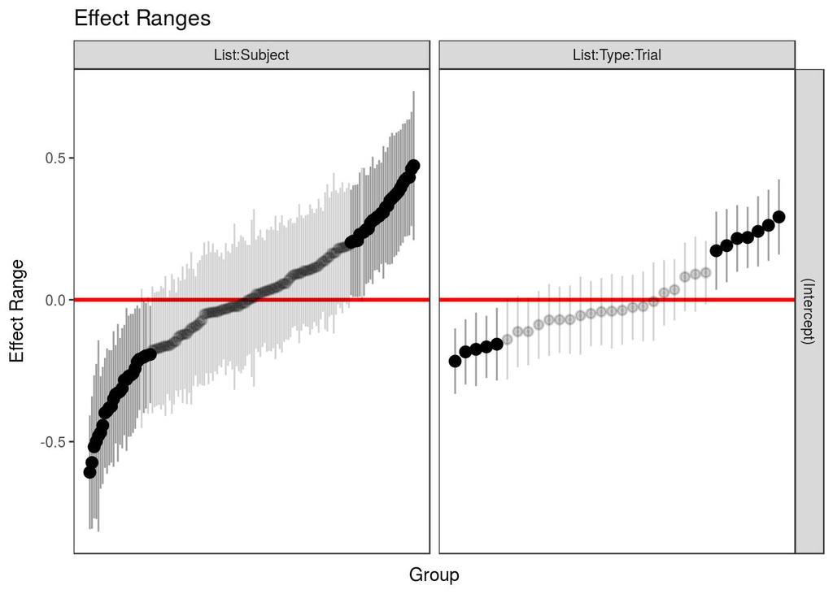

```r
detach("package:lmerTest",unload=TRUE)
require(merTools)
lmm <- lmer(formula = log(Time) ~ Type + LangLev + List + Type:LangLev + (1 | List:Subject) +
    (1 | List:Type:Trial), data = DLM, REML = FALSE)
plotREsim(REsim(lmm, n.sims= 100), level=0.95, stat="mean", sd = TRUE)
```

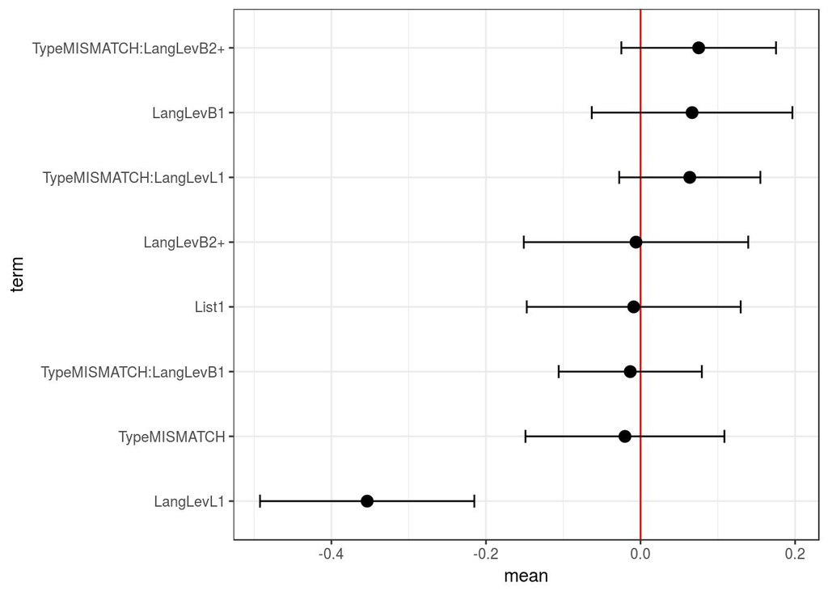

```r
plotFEsim(FEsim(lmm, n.sims = 100), level = 0.95, stat = 'mean', intercept = FALSE, sd=TRUE)
```

These plots also confirm our conclusions that `Type`, `List` and `Type:LangLev` are not significant.

## Conclusions

We plot the random and the fixed effects together with their 95% confidence levels in the figure. The confidence levels are obtained by the estimated standard deviation and the normal distribution. However, other analysis with boostrapped confidence intervals confirmed the same conclusions.

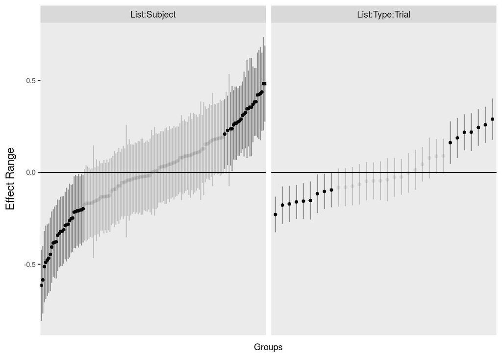

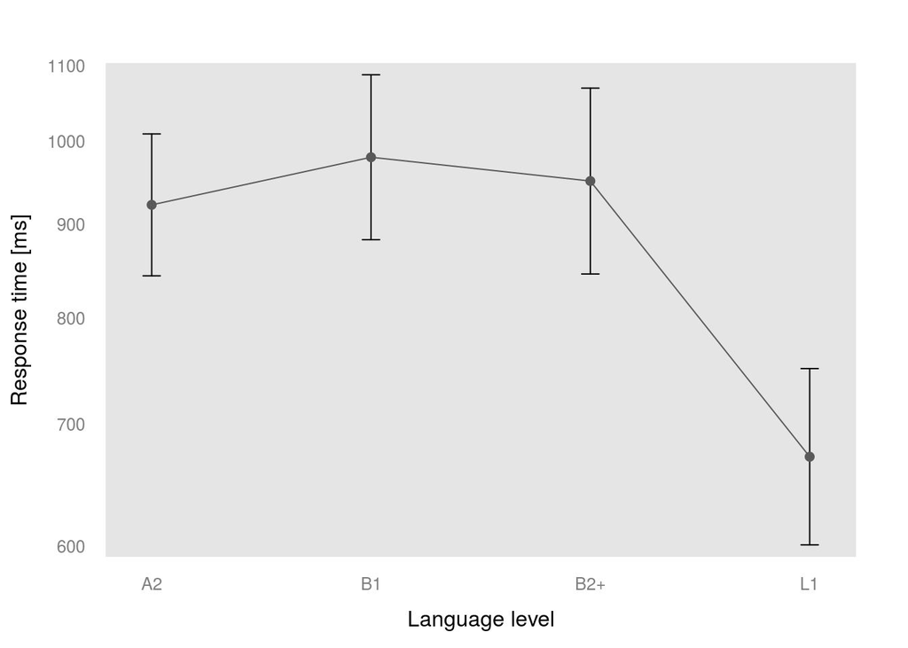

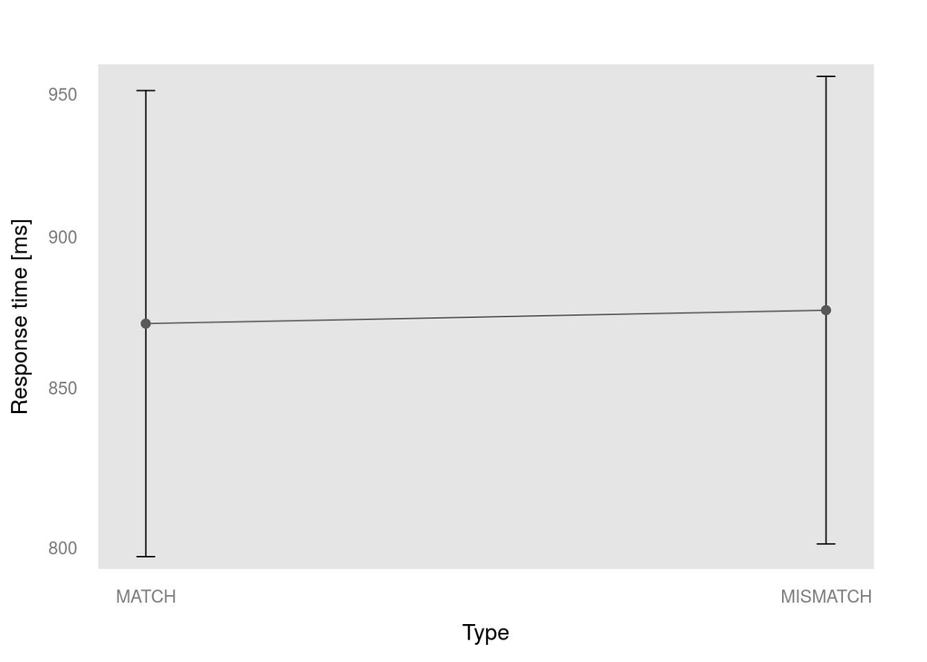

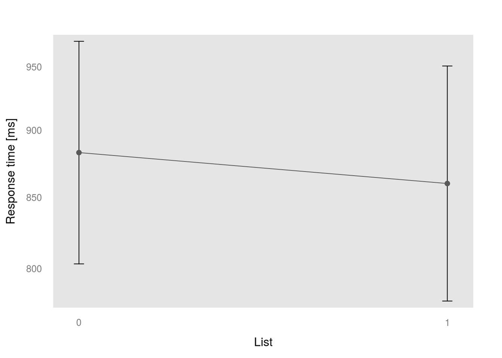

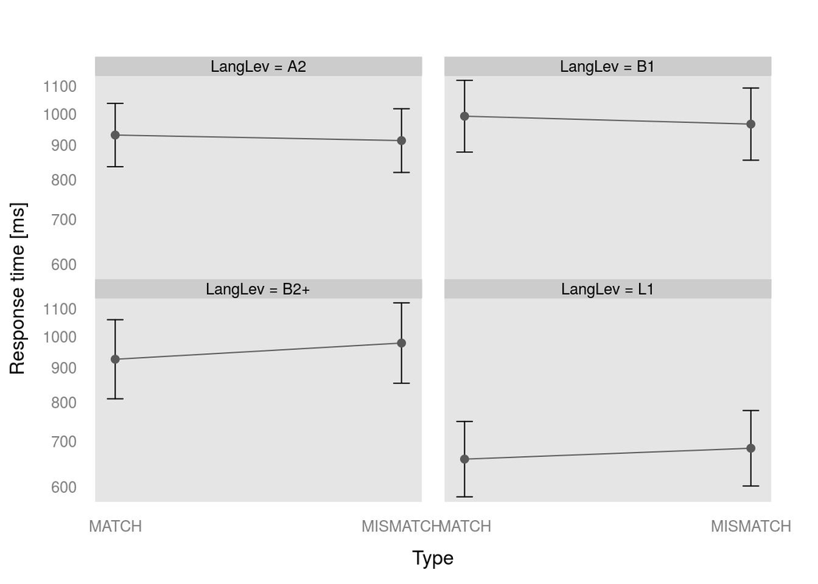

From the figure we can observe that the random effects cause often a significant effect by shifting the intercept by a quantity larger than zero. For the fixed effects we transformed back the effects in the linear time scale of milliseconds. It is evident that L1 speakers have a shorter reaction time and that `Type` and `List` do not have a significant impact.

## Diagnostic plots

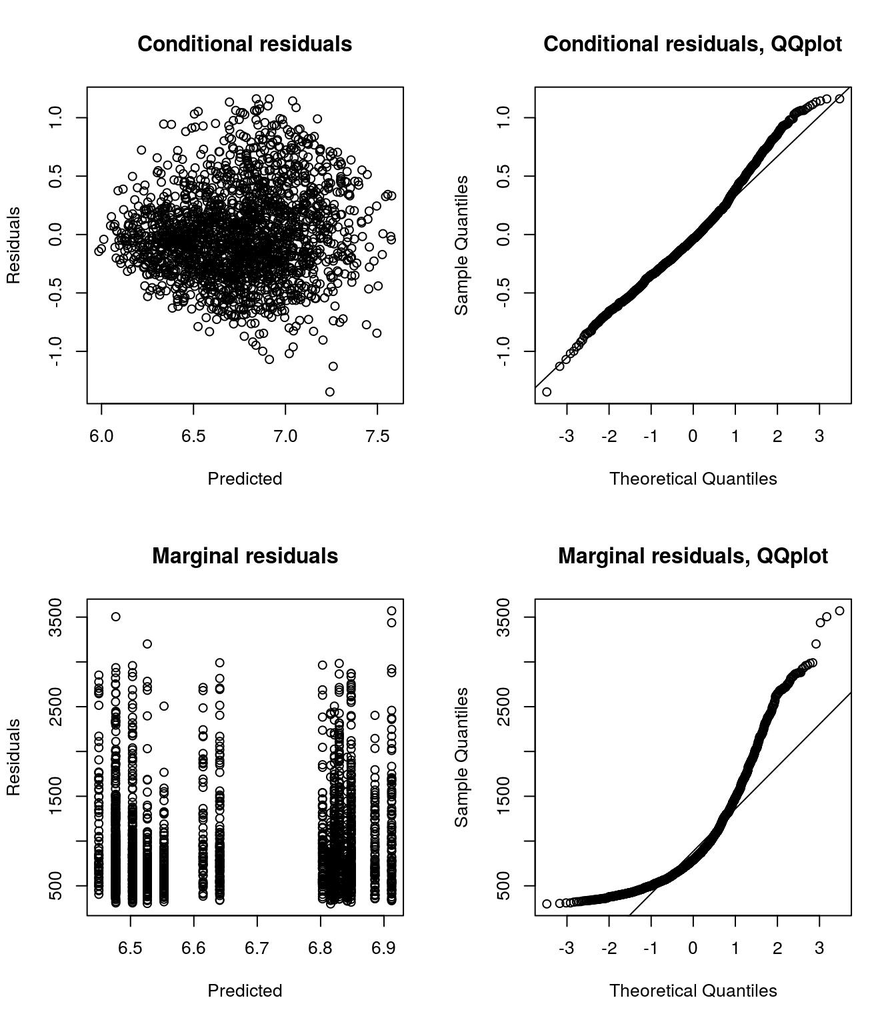

The joint qqplot looks normal. The marginal look less compliant with the normality assumptions.